# 観察

ここでの観察とは、研究者が調査時に行う動物行動の直接観察のことをさす。  
動物の行動観察は一朝一夕で見につくものではない。  
how toの事柄のように思われるが、フィールドで行う直接観察は頭で考えている暇はなく、体で反応できないといけない。なので、観察する前に様々なことを想定し整理する必要がある。  
筆者の経験をもとに観察についてまとめていく。

## 個体識別方法

ここで挙げる例は識別できていない状態の人に向けた識別するうえでのヒントにすぎない。  
識別が一番上達する方法は、

1. とにかく真摯に対象動物を見つめ、
2. スケッチ（似顔絵など）を描き、
3. 写真を撮る。

このサイクルを続ける意外に上達する手段はない。識別ポイントは人によって違うことが多いので、他人がつくった識別情報はわからないことも多々ある。最後は結局自分自身で築き上げた判断基準から識別するしかない。  
ここでは、筆者の研究対象であったニホンザルを例に個体識別の方法を説明していく。

### 個体の特徴を抑える

スケッチで書ける特徴を３つ、見つけてみよう。  
特徴が１つだけだと他個体と同じ特徴である可能性がまだ高い、２つでも心もとない。３つ見つけられれば、全く同じ特徴をもった紛らわしい個体（性・年齢も似通った個体）はいないはずだ。

**初心者レベル**

- 顔
- 手足の指
- 尾の長さ・曲がり具合
- 身体の大きさ・太り具合
- 乳首の長さ・左右の長さの偏り

**中級レベル**

- 毛並み
- 顔やお尻の色具合
- 声

**上級者レベル**

- 歩き方
- シルエット
- 顔の雰囲気

### 個体識別の手順

慣れていない最初のうちは、持ち合わせている情報をフィルターリングすることで個体識別できる可能性がぐっと高まる。

1. **群れ識別**
2. **属性分け**
   1. **性・年齢クラス**  
      オス・メスの区別。アカンボウ・コドモ・ワカモノ・オトナの区別。
   2. **発情の有無**  
      季節性繁殖する動物では有効なことが多い。
   3. **子持ちの有無**  
      アカンボウの有無、子のきょうだい構成（性・年齢の組み合わせ）などから判断。
3. **周辺個体情報**  
   よく近接している個体数のちがいや特徴をつかみやすい個体が近くにいるか等。

### 似顔絵を描く

裸眼もしくは双眼鏡で分かる特徴を似顔絵にする。写真よりも敢えて抽象度を上げることでどこに注目すればいいのかが分かりやすくなる利点がある。

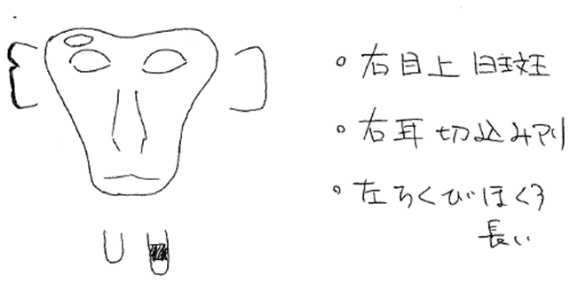

似顔絵の見本

### 写真を撮る

スマホはNG！  
望遠機能がない、というのが一番の理由である。20-35倍の光学ズームができるとだいぶ識別するのに使える写真が撮れる。デジタルズームは画像が荒くなるので注意。

## 観察方法

### 全生起サンプリング

### ワンゼロサンプリング

### アドリブサンプリング